# Stroop Effect by Burcu Kurtaran

# Introduction

The Stroop effect is a psychological occurrence named after American psychologist, John Ridley Stroop, who describes the effect as a demostration of interference in the reaction time of a task.[1] A typical example of such phenomenon can be well demonstrated by the Interactive Stroop Effect Experiment, which is described in detail by the following section.

# The Experiment

In a Stroop task, participants are presented with a list of words, with each word displayed in a color of ink. The participant’s task is to say out loud the color of the ink in which the word is printed. The task has two conditions: a congruent words condition, and an incongruent words condition. In the congruent words condition, the words being displayed are color words whose names match the colors in which they are printed: for example RED, BLUE. In the incongruent words condition, the words displayed are color words whose names do not match the colors in which they are printed: for example PURPLE, ORANGE. In each case, we measure the time it takes to name the ink colors in equally-sized lists. Each participant will go through and record a time from each condition.

# Data

The task has two conditions: a congruent words condition, and an incongruent words condition. In each case the time it takes to name the ink colors in equally-sized lists is measured. Each participant will go through and record a time from each condition.

- In the congruent words condition, the words being displayed are color words whose names match the colors in which they are printed.
- In the incongruent words condition, the words displayed are color words whose names do not match the colors in which they are printed.

```r
stroopEffect <- read.csv("stroopdata.csv")

stroopEffect
```

```
##    Congruent Incongruent
## 1     12.079      19.278
## 2     16.791      18.741
## 3      9.564      21.214
## 4      8.630      15.687
## 5     14.669      22.803
## 6     12.238      20.878
## 7     14.692      24.572
## 8      8.987      17.394
## 9      9.401      20.762
## 10    14.480      26.282
## 11    22.328      24.524
## 12    15.298      18.644
## 13    15.073      17.510
## 14    16.929      20.330
## 15    18.200      35.255
## 16    12.130      22.158
## 17    18.495      25.139
## 18    10.639      20.429
## 19    11.344      17.425
## 20    12.369      34.288
## 21    12.944      23.894
## 22    14.233      17.960
## 23    19.710      22.058
## 24    16.004      21.157
```

As shown by the R outputs below, the average times of the 24 participants performing the task under the congruent words condition and the incongruent words condition are xc¯=14.05113s and xi¯=22.01592s respectively.

The sample standard deviations of the two conditions are sc = 3.559358 and si = 4.797057.

The difference between the two average times is xc¯ - xi¯=-7.964792s, and the standard deviation of the difference between two conditions in time is sd=4.864827.

```r
summary(stroopEffect)
```

```
##    Congruent      Incongruent
##  Min.   : 8.63   Min.   :15.69
##  1st Qu.:11.90   1st Qu.:18.72
##  Median :14.36   Median :21.02
##  Mean   :14.05   Mean   :22.02
##  3rd Qu.:16.20   3rd Qu.:24.05
##  Max.   :22.33   Max.   :35.26
```

```r
AvgCongruent = mean(stroopEffect[["Congruent"]])
AvgIncongruent = mean(stroopEffect[["Incongruent"]])
SdCongruent = sd(stroopEffect[["Congruent"]])
SdIncongruent = sd(stroopEffect[["Incongruent"]])
MeanDiff = AvgCongruent - AvgIncongruent
SdDiff = SdCongruent - SdIncongruent

stroopEffectVar <- data.frame(AvgCongruent,
                              AvgIncongruent,
                              SdCongruent,
                              SdIncongruent,
                              MeanDiff,
                              SdDiff)

stroopEffectVar
```

```
##   AvgCongruent AvgIncongruent SdCongruent SdIncongruent  MeanDiff
## 1     14.05113       22.01592    3.559358      4.797057 -7.964792
##      SdDiff
## 1 -1.237699
```

# Independent and dependent variables

The independent variable is the congruency condition - whether the name of the color matches with the ink color.

The dependent variable is the time it takes to name the ink colors in equally-sized lists.

# Appropriate set of hypotheses for this task and statistical test

The recommended statistical test we should use for the Stroop experiment is a T-test. Beacuse we don’t know the mean of the total population, but we have detailed data on a sampled group for both the congruent and incongruent tests.

In addition, we only have a data set of 24 people in the sample making it more better to use T-test to calculate our statistical test.

We could sum up the selection of T-Test:

- The variance of the population is unknown.
- The sample size is small (n=24 < 30).
- The same participants are asked to perform the task under both the congruent words condition and the incongruent words condition.
- Dependent: Because there is only one sample that has been tested twice.
- Paired: Because our participants were measured at two time points (so each individual has two measurements).

An appropriate set of hypotheses for the task is:

H0:μc−μi≥0

Ha:μc−μi<0

The null hypothesis (H0) is that the mean of the population reaction time of the task under the incongruent words condition is not significantly longer than that of the congruent words condition. The alternative hypothesis (Ha) is that the mean of the population reaction time of the task under the incongruent words condition is significantly longer than that of the congruent words condition.

# Descriptive statistics

I need to do some changes, so the data becomes more comfortable to work in R. “tidyr” is a package that makes it easy to “tidy” your data. Tidy data is data that’s easy to work with: it’s easy to munge (with dplyr), visualise (with ggplot2 or ggvis).[2]

```r
library(tidyr)
library(dplyr)
stroopEffect.subject <- mutate(stroopEffect, subject = 1:nrow(stroopEffect))

tidy.stroopEffect <- gather(stroopEffect.subject, congruency, time, -subject)

tidy.stroopEffect %>%
    group_by(congruency) %>%
    summarise(mean(time), median(time), sd(time), var(time))
```

```
## # A tibble: 2 x 5
##    congruency `mean(time)` `median(time)` `sd(time)` `var(time)`
##         <chr>        <dbl>          <dbl>      <dbl>       <dbl>
## 1   Congruent     14.05113        14.3565   3.559358    12.66903
## 2 Incongruent     22.01592        21.0175   4.797057    23.01176
```

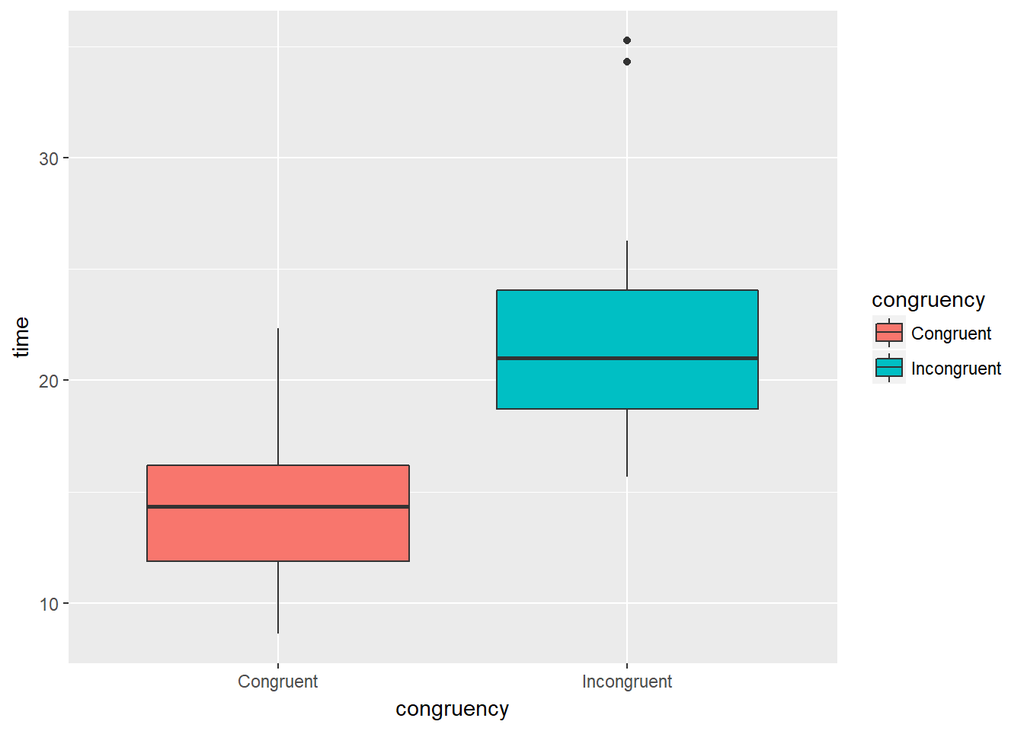

```r
library(ggplot2)

ggplot(tidy.stroopEffect, aes(y = time, x = congruency, fill = congruency)) +
  geom_boxplot()
```

The boxplot indicates that the two groups have significant difference in median times, and the two groups also have different ranges.

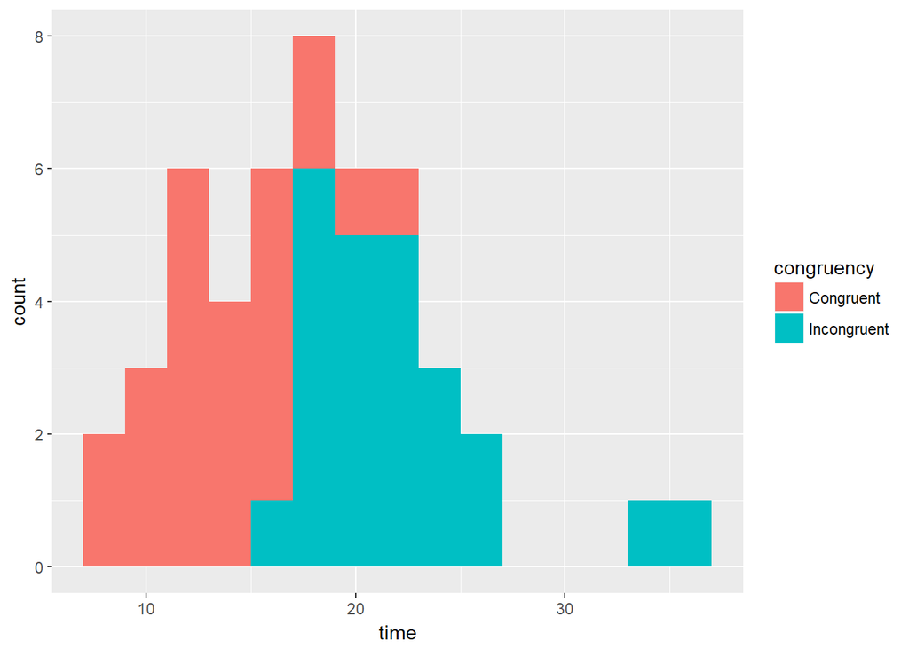

```r
ggplot(tidy.stroopEffect, aes(x = time, fill = congruency)) +
  geom_histogram(binwidth = 2)
```

# Dependent t-test for paired samples

It is time to make t-test. We perform two-sided test with alpha = 0.05, sample size n = 24 and degrees of freedom df = 23.

```r
# Verify using the t.test() function
t.test(x = stroopEffect$Congruent,
       y = stroopEffect$Incongruent,
       alternative = "two.sided",
       mu = 0,
       paired = TRUE,
       conf.level = 0.95)
```

```
##
##  Paired t-test
##
## data:  stroopEffect$Congruent and stroopEffect$Incongruent
## t = -8.0207, df = 23, p-value = 4.103e-08
## alternative hypothesis: true difference in means is not equal to 0
## 95 percent confidence interval:
##  -10.019028  -5.910555
## sample estimates:
## mean of the differences
##               -7.964792
```

# Conclusion

Since the p-value is less than 0.05, we reject the null hypothesis. We could conclude that the difference between congruence and incongruence group time difference is the stroop effect is present. This is in line with my expectation.

We are 95% confident that the true difference between the congruence and incongruence group average times is between -10.019028 and -5.910555.

# References

- Wikipedia: https://en.wikipedia.org/wiki/Stroop_effect
- Introducing tidyr https://blog.rstudio.com/2014/07/22/introducing-tidyr/
- Package ‘tidyr’ https://cran.r-project.org/web/packages/tidyr/tidyr.pdf